# ggplot2 (Swirl)

##### Example 2.1.3:

- Just add a fifth argument, geom, and using the R function c(),
- set it equal to the concatenation of the two strings “point” and “smooth”. The - first refers to the data points and
  - second to the trend lines we want plotted.

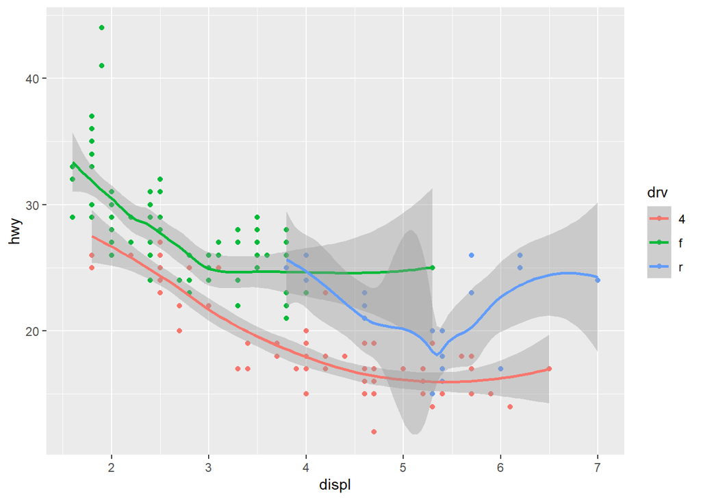

```r
qplot(displ,hwy,data = mpg,color=drv,geom = c("point","smooth"))
```

##### Explanation 2.1.3:

- The gray areas surrounding each trend lines.
- These indicate the 95% confidence intervals for the lines.

##### Example 2.1.4:

Plot a Scatterplot which has property values in the form of intervals on x-axis axis and individual value of property on y axis.

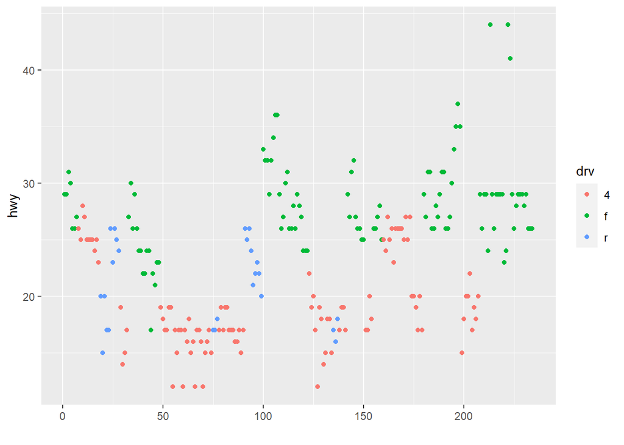

```r
qplot(y= hwy,data = mpg,color=drv)
```

##### Explanation 2.1.4:

- We see the x-axis ranges from 0 to 250 and we remember that we had 234 data points in our set,
- so we can infer that each point in the plot represents one of the hwy values (indicated by the y-axis).

##### Verify 2.1.4:

```r
print(mpg$hwy)
```

```
##   [1] 29 29 31 30 26 26 27 26 25 28 27 25 25 25 25 24 25 23 20 15 20 17 17 26 23
##  [26] 26 25 24 19 14 15 17 27 30 26 29 26 24 24 22 22 24 24 17 22 21 23 23 19 18
##  [51] 17 17 19 19 12 17 15 17 17 12 17 16 18 15 16 12 17 17 16 12 15 16 17 15 17
##  [76] 17 18 17 19 17 19 19 17 17 17 16 16 17 15 17 26 25 26 24 21 22 23 22 20 33
## [101] 32 32 29 32 34 36 36 29 26 27 30 31 26 26 28 26 29 28 27 24 24 24 22 19 20
## [126] 17 12 19 18 14 15 18 18 15 17 16 18 17 19 19 17 29 27 31 32 27 26 26 25 25
## [151] 17 17 20 18 26 26 27 28 25 25 24 27 25 26 23 26 26 26 26 25 27 25 27 20 20
## [176] 19 17 20 17 29 27 31 31 26 26 28 27 29 31 31 26 26 27 30 33 35 37 35 15 18
## [201] 20 20 22 17 19 18 20 29 26 29 29 24 44 29 26 29 29 29 29 23 24 44 41 29 26
## [226] 28 29 29 29 28 29 26 26 26
```

- Comparing the values of mpg$hwy with the plot,
- we see the first entries in the vector (29, 29, 31, 30,…) correspond to the leftmost points in the the plot (in order), and
- the last entries in myhigh (28,29, 26, 26, 26) correspond to the rightmost plotted points.
- So, specifying the y parameter only, without an x argument, plots the values of the y argument in the order in which they occur in the data.

### 2.2. Boxplot

The all-purpose qplot can also create box and whisker plots.

##### Example 2.2.1:

- Call qplot now with 4 arguments.
  - First specify the **variable by which you’ll split the data**,
    - in this case **drv**,
  - then specify the **variable which you want to examine**,
    - in this case **hwy**.
  - The third argument is **data**
    - **data = mpg**,
  - and the fourth, the **geom**,
    - set equal to the string “**boxplot**” (**geom = "boxplot**)

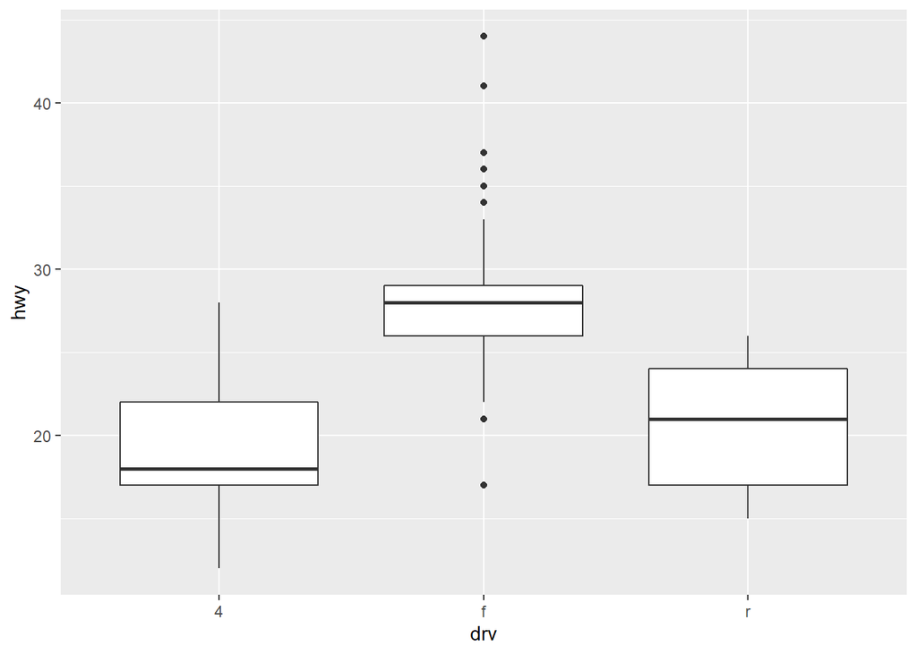

```r
qplot(drv,hwy, data = mpg, geom = "boxplot")
```

##### Explanation 2.2.1:

- We see 3 boxes, one for each drive.

##### Variation 2.2.1.1:

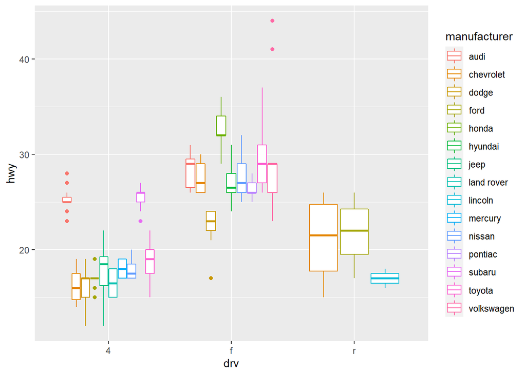

```r
qplot(drv,hwy, data = mpg, geom = "boxplot",color = manufacturer)
```

##### Explanation 2.2.1.1:

- qplot’s capabilities.
  - Notice that there are still 3 regions of the plot (determined by the factor drv).
  - Each is subdivided into several boxes depicting different manufacturers.